# ECON413

Abdullah Yüksel, Davut Emre Özkan, Yasemin Hece

# Covid-19 Vaccination Effectiveness on Cases and Deaths

### Introduction

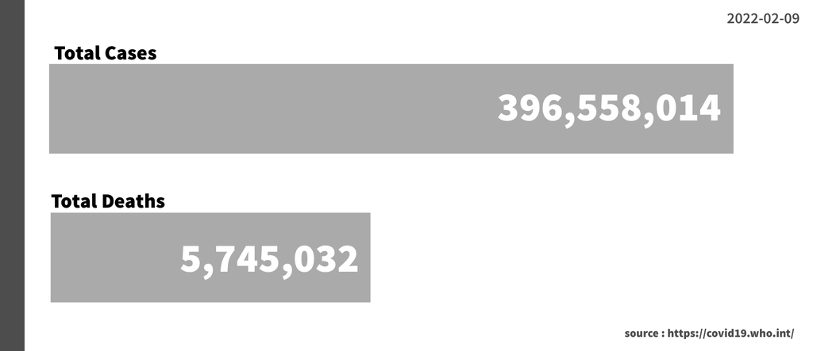

The new type of coronavirus, also known as SARS-CoV-2, which is known to have emerged in Wuhan, China in 2019, spread to all parts of the world in the future, and the World Health Organization declared a pandemic on March 11, 2020. The virus, which manifested itself with various symptoms, was more severe in people with chronic diseases and in elderly people. It was tried to prevent the spread with individual and social measures. As of 2021, vaccination studies have started.Currently, there are a total of variety variants, including alpha, beta, gamma, delta, and omicron.  
In this project, our aimis to examine the number of cases and deaths, country restrictions and the number of vaccinations for countries over time, and to analyze the effect of vaccination on cases and deaths as a result of regression analysis.

### Literature survey

#### **Effectiveness of COVID-19 vaccines against SARS-CoV-2 variants of concern: a systematic review and meta-analysis**

It is published in China. This study is a meta-analysis to provide a comprehensive overview of the effectiveness of the Covid-19 vaccines.

- Method
  - Published and preprinted all randomized controlled trials, cohort, and case control studies that evaluates the VE were searched until 31 August 2021.
  - 7 RCTs (51,169 participants)
  - 10 cohort studies (14,385,909 participants)
  - 16 case-control studies (734,607 cases)
  - Pooled estimates and 95% confidence intervals (CIs) were calculated using random-effects meta-analysis.
- Results
  - Full vaccination is effective against  
    Alpha with VE of 88.3% (95% CI, 82.4–92.2)  
    Beta/Gamma with VE of 70.7% (95% CI, 59.9–78.5)  
    Delta with VE of 71.6% (95% CI,64.1–77.4)
  - Partial vaccination is effective against  
    Alpha with VE of 59.0% (95% CI, 51.3–65.5)  
    Beta/Gamma with VE of 49.3% (95% CI, 33.0–61.6)  
    Delta with VE of 52.6% (95% CI, 43.3–60.4)

#### **Effectiveness of COVID-19 vaccines in preventing SARS-CoV-2 infection and hospitalisation, Navarre, Spain, January to April 2021**

This study, conducted in Spain, examined the spread of the vaccine to people in close contact with confirmed cases and its effect on symptoms.

- Method
  - Vaccine effectiveness was calculated as a percentage.
  - The relationship between vaccination and age groups was measured.
  - The effect of the increase in the number of doses on the effect of the vaccine was examined.
- Cohort
  - 20,961 close contacts of confirmed covid-19 cases
  - 7,240 (34.5%) were confirmed as infected with SARS-CoV-2,
  - 5,467 (26.1%) having symptomatic infections,
  - 559 (2.7%) needing hospitalisation for COVID-19
- Results
  - The covid-19 vaccine appears to have a moderate effect in preventing transmission, while a higher effect is seen in symptomatic and hospitalized cases.
  - It was observed that a single dose had a moderate effect and the second dose increased it.

#### **WHO - Evaluation of COVID-19 vaccine effectiveness**

We have benefited from the guidance of the World Healh Organization while we are doing our research. In this article, the WHO explains how to conduct a research more precisely. Most of the material guidance is about clinical studies, but one item is important for us.

For the primary analysis of VE studies, a conservative approach is recommended in considering a person as potentially protected from vaccination only from 14 days after the date of vaccination (the time required to achieve protection for the majority of vaccine recipients for most vaccines), for both first and (if applicable) second doses of vaccine. Secondary analyses with different time intervals post-vaccination can be conducted to help guide future policy.

Due to this advise of the WHO, we have used the 14-days lagged vaccination rates in our regression.

### Data Analysis

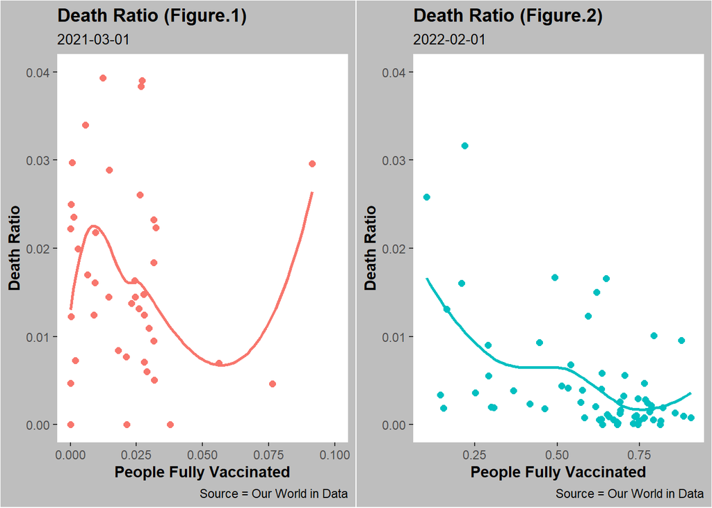

The first graph is from March 1, 2021. X-axis represents the proportion of full vaccinated (2 doses) people to the population of the country, Y-axis represents the deaths/cases ratio in March 1. There is no correlation or causal relationship between vaccinations and deaths. The graph is not clear.

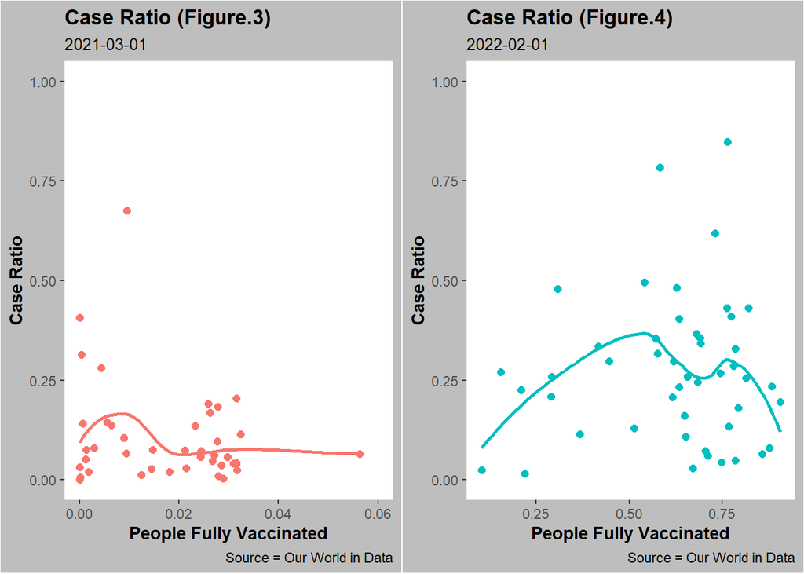

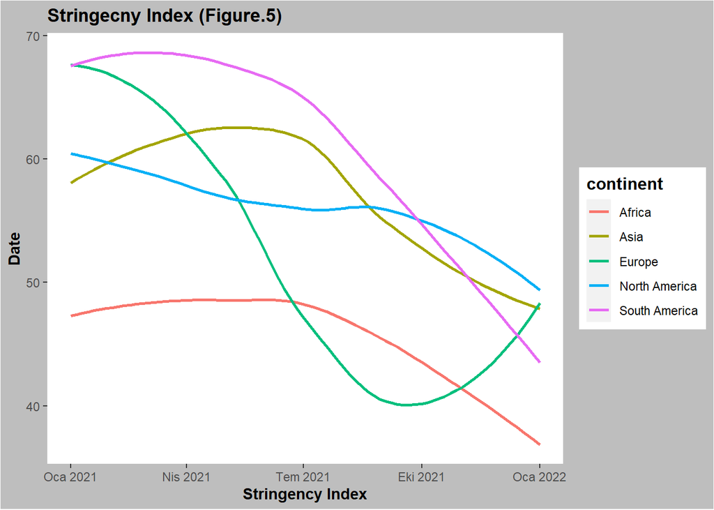

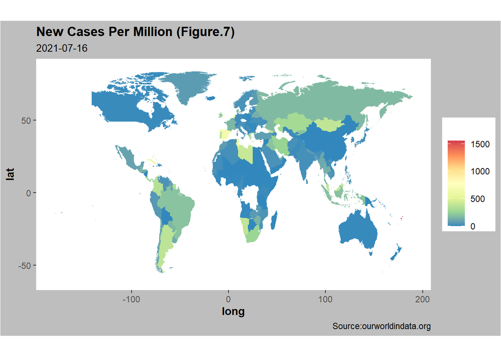

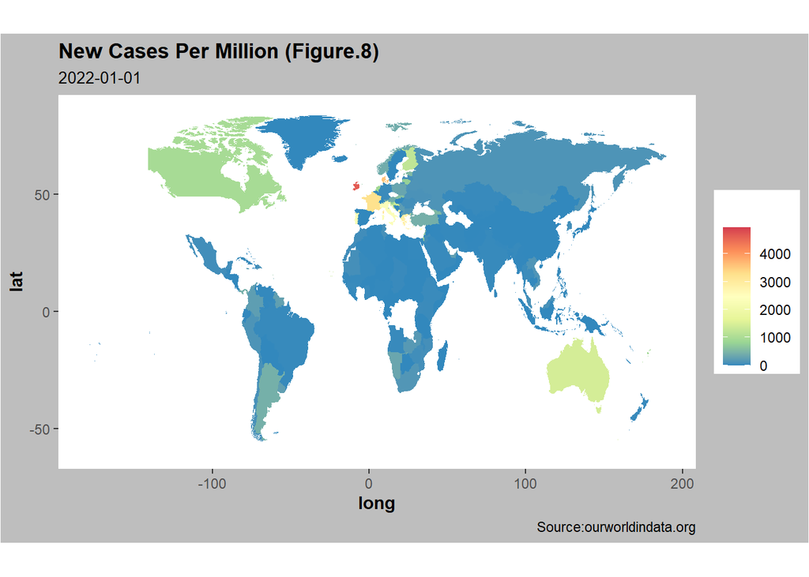

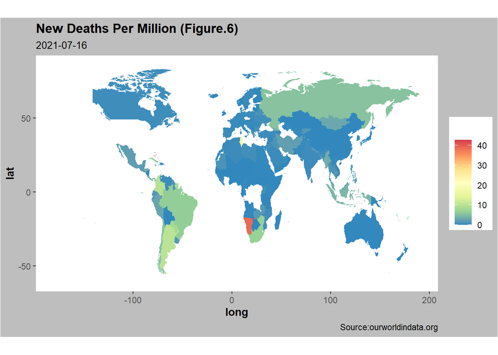

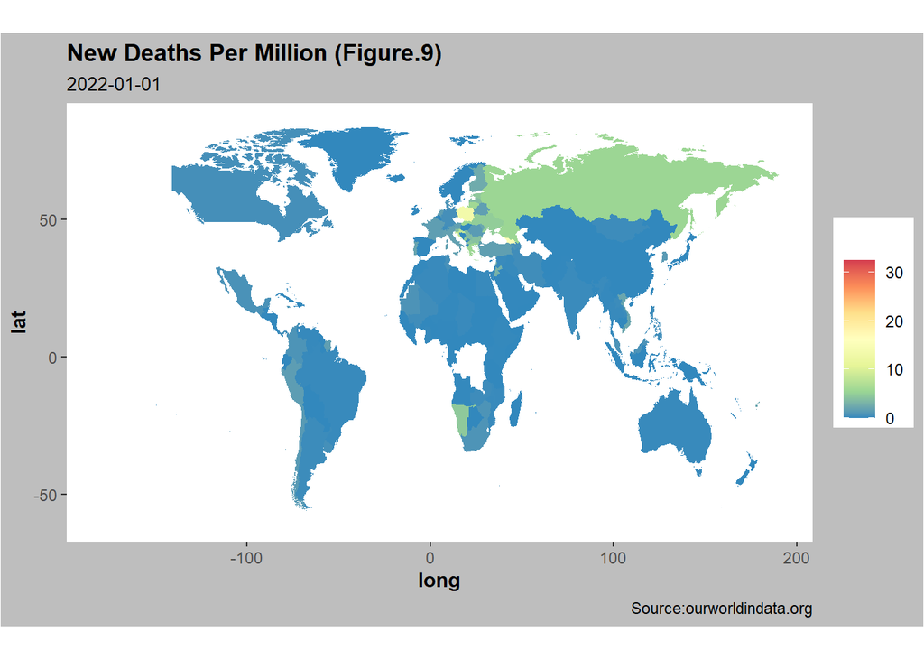

When we look at the new deaths per million between the two dates, we can see that there has been a significant decrease in the scale. On the other hand, while the maximum level was experienced in the South African country on 16-07-2021, it was experienced in the countries in the northwest of Turkey and some European countries on 01-01-2022.

### Case Model

$New Cases = -2147xVaccination + 0.07xActive + 0.04xTests - 18.97xDeaths$ $+ 268.26xResidential + 8253xReproduction - 32.08xStringency$

- new cases
  - New confirmed cases of COVID-19. Counts can include probable cases, where reported.
- vaccine
  - Vaccine is the percentage of people who fully vaccinated among the population. (at least 2 doses).
- active cases
  - The cumulative case number of last 14 days.
- new tests
  - New tests for COVID-19, daily.
- new deaths smoothed
  - New deaths attributed to COVID-19 (7-day smoothed). Counts can include probable deaths, where reported.
- residential
  - Mobility of Google users in residential.
- reproduction rate
  - Real-time estimate of the effective reproduction rate.
- stringency index
  - Government Response Stringency Index: composite measure based on 9 response indicators including school closures, workplace closures, and travel bans, rescaled to a value from 0 to 100 (100 = strictest response).

|  | new cases |  |  |
| --- | --- | --- | --- |
| Predictors | Estimates | CI | p |
| lag(people fully vaccinated rate, 14) | -2147.60 | -3513.08 – -782.13 | **0.002** |
| active cases 14 | 0.07 | 0.07 – 0.07 | **<0.001** |
| new tests | 0.04 | 0.04 – 0.04 | **<0.001** |
| new deaths smoothed | -18.97 | -20.36 – -17.59 | **<0.001** |
| residential | 268.26 | 189.29 – 347.24 | **<0.001** |
| reproduction rate | 8252.99 | 7317.15 – 9188.82 | **<0.001** |
| lag(stringency index, 7) | -32.08 | -60.29 – -3.88 | **0.026** |
| Observations | 18358 |  |  |
| R<sup>2</sup> / R<sup>2</sup> adjusted | 0.763 / 0.761 |  |  |

### Death Model

$deaths = -37.59*vaccine + 0.03*cases + 0.09*icu + 4.48*hospital - 0.32*policy$

|  | Dependent variable |  |  |
| --- | --- | --- | --- |
| Predictors | Estimates | CI | p |
| lag(people_fully_vaccinated_rate, 14) | -37.59 | -45.57 – -29.62 | **<0.001** |
| lag(active_cases_14_per_thousands, 14) | 0.03 | 0.02 – 0.03 | **<0.001** |
| lag(icu_patients, 14) | 0.09 | 0.09 – 0.10 | **<0.001** |
| lag(beds_per_active, 14) | 4.48 | 3.45 – 5.52 | **<0.001** |
| lag(stringency_index, 14) | -0.32 | -0.49 – -0.15 | **<0.001** |
| Observations | 10182 |  |  |
| R<sup>2</sup> / R<sup>2</sup> adjusted | 0.806 / 0.805 |  |  |

### Result

Both models are built with linear regression for panel data. When the r square values are examined, both models are significant, and when the t values are examined, all variables are individually significant.  
According to case model, when people fully vaccinated rate increases by 1%, new cases will decrease by -21.47.  
According to death model, when people fully vaccinated rate increases by 1%, new deaths will decrease by 0.37.  
As a result, vaccination has an considerable effect on both cases and deaths. Missing values in both models, insufficient tests and not taking into account the effect of variants may be the limitations of the models.